# BAN614 Winter 2023: Final Project

A big part of customer relationship management involves efforts to retain existing customers. This is because in many cases the costs incurred to attract new customers are much larger than the costs to retain the existing customers. As part of the class project, your goal is to analyze customer data of a telecommunications company and identify the ones that are likely to leave so that you can take some action to retain them by offering incentives. The dataset contains current customers as well as customers who have left. The description of the dataset is below: 1. Gender: Male, Female 2. SeniorCitizen: Whether the customer is a senior citizen or not (1, 0) 3. Partner: Has a partner (Yes, No) 4. Dependents: Has dependents (Yes, No) 5. Tenure: Number of months with the company 6. PhoneService: Has a phone service (Yes, No) 7. MultipleLines: Has multiple lines (Yes, No, No phone service) 8. InternetService: Customer’s Internet Service Provider (DSL, Fiber optic, No) 9. OnlineSecurity: Customer has online security or not (Yes, No, No internet service) 10. OnlineBackup: Customer has online backup or not (Yes, No, No internet service) 11. DeviceProtection: Customer has device protection or not (Yes, No, No internet service) 12. TechSupport: Customer has tech. support or not (Yes, No, No internet service) 13. StreamingTV : Customer has streaming TV or not (Yes, No, No internet service) 14. StreamingMovies: Customer has streaming movies or not (Yes, No, No internet service) 15. Contract: The contract term of the customer (Month-to-month, One year, Two year) 16. PaperlessBilling: Customer has paperless billing or not (Yes, No) 17. PaymentMethod: The customer’s payment method (Electronic check, Mailed check, Bank transfer (automatic), Credit card (automatic)) 18. MonthlyCharges: The amount charged to the customer monthly 19. TotalCharges: The total amount charged to the customer 20. Status: Current or Left

*A. Scope of Project* Organize your report into eight sections as described below: *1. Data preparation and Exploratory Data Analysis* * Follow concepts learnt in Week 2 to clean the data. If there are missing values then indicate how you plan to work with them. ## Import libraries going to be used in this project

```r
library(tidymodels)
# Load the e1071 package to access Naive Bayes
library(e1071)
library(car)
library(MASS)
library(caret)
# Library for tree
library(tree)
```

## Check missing data

```r
is.na(CustomerRetention) %>% colSums()
```

```
          Gender    SeniorCitizen          Partner       Dependents           Tenure     PhoneService    MultipleLines  InternetService   OnlineSecurity     OnlineBackup DeviceProtection      TechSupport      StreamingTV  StreamingMovies
               0                0                0                0                0                0                0                0                0                0                0                0                0                0
        Contract PaperlessBilling    PaymentMethod   MonthlyCharges     TotalCharges           Status
               0                0                0                0                0                0
```

## Fill the missing data

Fills missing values in with median

```r
meanMissing = median(CustomerRetention$TotalCharges,na.rm =  TRUE)
CustomerRetention <- CustomerRetention %>%
                    mutate(TotalCharges = ifelse(is.na(TotalCharges), meanMissing,                                      TotalCharges))
```

## Confirm there are no missing data

```r
is.na(CustomerRetention) %>% colSums()
```

```
          Gender    SeniorCitizen          Partner       Dependents           Tenure     PhoneService    MultipleLines  InternetService   OnlineSecurity     OnlineBackup DeviceProtection      TechSupport      StreamingTV  StreamingMovies
               0                0                0                0                0                0                0                0                0                0                0                0                0                0
        Contract PaperlessBilling    PaymentMethod   MonthlyCharges     TotalCharges           Status
               0                0                0                0                0                0
```

*OBSERVATION:* The dataset contained no missing data.

- Explore the dataset and use data visualization to describe underlying trends. You can make observations on the distributions of each variable.

## View of the dataset

```r
glimpse(CustomerRetention)
```

```
Rows: 6,999
Columns: 20
$ Gender           <fct> Female, Male, Male, Male, Female, Female, Male, Female, Female, Male, Male, Male, Male, Male, Male, Female, Female, Male, Female, Female, Male, Male, Male, Female, Male, Female, Male, Male, Male, Female, Female, Male, Femal…
$ SeniorCitizen    <fct> 0, 0, 0, 0, 0, 0, 0, 0, 0, 0, 0, 0, 0, 0, 0, 0, 0, 0, 0, 0, 1, 0, 0, 0, 0, 0, 0, 0, 0, 0, 1, 1, 0, 0, 1, 0, 0, 0, 0, 0, 0, 0, 0, 0, 0, 0, 0, 0, 0, 0, 1, 0, 1, 1, 1, 1, 0, 1, 0, 0, 0, 0, 0, 0, 0, 0, 0, 0, 0, 0, 0, 0, 1, 0, 0…
$ Partner          <fct> Yes, No, No, No, No, No, No, No, Yes, No, Yes, No, Yes, No, No, Yes, No, No, Yes, No, No, Yes, No, Yes, Yes, No, Yes, Yes, Yes, No, Yes, Yes, Yes, No, No, Yes, No, No, No, No, Yes, Yes, Yes, No, Yes, No, No, No, No, Yes, No…
$ Dependents       <fct> No, No, No, No, No, No, Yes, No, No, Yes, Yes, No, No, No, No, Yes, No, Yes, Yes, No, No, No, No, No, Yes, No, Yes, Yes, No, Yes, No, No, Yes, No, No, Yes, No, No, No, No, Yes, Yes, Yes, No, No, No, No, No, No, Yes, No, No,…
$ Tenure           <int> 1, 34, 2, 45, 2, 8, 22, 10, 28, 62, 13, 16, 58, 49, 25, 69, 52, 71, 10, 21, 1, 12, 1, 58, 49, 30, 47, 1, 72, 17, 71, 2, 27, 1, 1, 72, 5, 46, 34, 11, 10, 70, 17, 63, 13, 49, 2, 2, 52, 69, 43, 15, 25, 8, 60, 18, 63, 66, 34, 7…
$ PhoneService     <fct> No, Yes, Yes, No, Yes, Yes, Yes, No, Yes, Yes, Yes, Yes, Yes, Yes, Yes, Yes, Yes, Yes, Yes, Yes, No, Yes, Yes, Yes, Yes, Yes, Yes, No, Yes, Yes, Yes, Yes, Yes, Yes, Yes, Yes, Yes, Yes, Yes, Yes, Yes, Yes, Yes, Yes, Yes, Yes…
$ MultipleLines    <fct> No phone service, No, No, No phone service, No, Yes, Yes, No phone service, Yes, No, No, No, Yes, Yes, No, Yes, No, Yes, No, No, No phone service, No, No, Yes, No, No, Yes, No phone service, Yes, No, Yes, No, No, No, No, Ye…
$ InternetService  <fct> DSL, DSL, DSL, DSL, Fiber optic, Fiber optic, Fiber optic, DSL, Fiber optic, DSL, DSL, No, Fiber optic, Fiber optic, Fiber optic, Fiber optic, No, Fiber optic, DSL, Fiber optic, DSL, No, No, DSL, DSL, DSL, Fiber optic, DSL,…
$ OnlineSecurity   <fct> No, Yes, Yes, Yes, No, No, No, Yes, No, Yes, Yes, No internet service, No, No, Yes, Yes, No internet service, Yes, No, No, No, No internet service, No internet service, No, Yes, Yes, No, No, Yes, No, Yes, No, Yes, No intern…
$ OnlineBackup     <fct> Yes, No, Yes, No, No, No, Yes, No, No, Yes, No, No internet service, No, Yes, No, Yes, No internet service, No, No, Yes, No, No internet service, No internet service, Yes, Yes, Yes, Yes, Yes, Yes, No, Yes, No, Yes, No inter…
$ DeviceProtection <fct> No, Yes, No, Yes, No, Yes, No, No, Yes, No, No, No internet service, Yes, Yes, Yes, Yes, No internet service, Yes, Yes, Yes, Yes, No internet service, No internet service, No, No, No, No, No, Yes, No, Yes, Yes, Yes, No inte…
$ TechSupport      <fct> No, No, No, Yes, No, No, No, No, Yes, No, No, No internet service, No, No, Yes, Yes, No internet service, No, Yes, No, No, No internet service, No internet service, Yes, Yes, No, No, No, Yes, No, Yes, No, Yes, No internet s…
$ StreamingTV      <fct> No, No, No, No, No, Yes, Yes, No, Yes, No, No, No internet service, Yes, Yes, Yes, Yes, No internet service, Yes, No, No, No, No internet service, No internet service, No, No, No, Yes, No, Yes, Yes, No, Yes, No, No internet…
$ StreamingMovies  <fct> No, No, No, No, No, Yes, No, No, Yes, No, No, No internet service, Yes, Yes, Yes, Yes, No internet service, Yes, No, Yes, Yes, No internet service, No internet service, No, No, No, Yes, No, Yes, Yes, No, Yes, No, No interne…
$ Contract         <fct> Month-to-month, One year, Month-to-month, One year, Month-to-month, Month-to-month, Month-to-month, Month-to-month, Month-to-month, One year, Month-to-month, Two year, One year, Month-to-month, Month-to-month, Two year, One…
$ PaperlessBilling <fct> Yes, No, Yes, No, Yes, Yes, Yes, No, Yes, No, Yes, No, No, Yes, Yes, No, No, No, No, Yes, Yes, No, No, Yes, No, Yes, Yes, No, Yes, Yes, Yes, Yes, No, No, No, No, Yes, Yes, Yes, Yes, No, Yes, No, Yes, Yes, Yes, No, Yes, Yes,…
$ PaymentMethod    <fct> Electronic check, Mailed check, Mailed check, Bank transfer (automatic), Electronic check, Electronic check, Credit card (automatic), Mailed check, Electronic check, Bank transfer (automatic), Mailed check, Credit card (aut…
$ MonthlyCharges   <dbl> 29.85, 56.95, 53.85, 42.30, 70.70, 99.65, 89.10, 29.75, 104.80, 56.15, 49.95, 18.95, 100.35, 103.70, 105.50, 113.25, 20.65, 106.70, 55.20, 90.05, 39.65, 19.80, 20.15, 59.90, 59.60, 55.30, 99.35, 30.20, 90.25, 64.70, 96.35, …
$ TotalCharges     <dbl> 29.85, 1889.50, 108.15, 1840.75, 151.65, 820.50, 1949.40, 301.90, 3046.05, 3487.95, 587.45, 326.80, 5681.10, 5036.30, 2686.05, 7895.15, 1022.95, 7382.25, 528.35, 1862.90, 39.65, 202.25, 20.15, 3505.10, 2970.30, 1530.60, 474…
$ Status           <fct> Current, Current, Left, Current, Left, Left, Current, Current, Left, Current, Current, Current, Current, Left, Current, Current, Current, Current, Left, Current, Left, Current, Left, Current, Current, Current, Left, Left, C…
```

## Convert status from character to factor

```r
CustomerRetention <- CustomerRetention %>%
                     mutate(Status = factor(Status),
                            SeniorCitizen = factor(SeniorCitizen))

glimpse(CustomerRetention)
```

```
Rows: 6,999
Columns: 20
$ Gender           <fct> Female, Male, Male, Male, Female, Female, Male, Female, Female, Male, Male, Male, Male, Male, Male, Female, Female, Male, Female, Female, Male, Male, Male, Female, Male, Female, Male, Male, Male, Female, Female, Male, Femal…
$ SeniorCitizen    <fct> 0, 0, 0, 0, 0, 0, 0, 0, 0, 0, 0, 0, 0, 0, 0, 0, 0, 0, 0, 0, 1, 0, 0, 0, 0, 0, 0, 0, 0, 0, 1, 1, 0, 0, 1, 0, 0, 0, 0, 0, 0, 0, 0, 0, 0, 0, 0, 0, 0, 0, 1, 0, 1, 1, 1, 1, 0, 1, 0, 0, 0, 0, 0, 0, 0, 0, 0, 0, 0, 0, 0, 0, 1, 0, 0…
$ Partner          <fct> Yes, No, No, No, No, No, No, No, Yes, No, Yes, No, Yes, No, No, Yes, No, No, Yes, No, No, Yes, No, Yes, Yes, No, Yes, Yes, Yes, No, Yes, Yes, Yes, No, No, Yes, No, No, No, No, Yes, Yes, Yes, No, Yes, No, No, No, No, Yes, No…
$ Dependents       <fct> No, No, No, No, No, No, Yes, No, No, Yes, Yes, No, No, No, No, Yes, No, Yes, Yes, No, No, No, No, No, Yes, No, Yes, Yes, No, Yes, No, No, Yes, No, No, Yes, No, No, No, No, Yes, Yes, Yes, No, No, No, No, No, No, Yes, No, No,…
$ Tenure           <int> 1, 34, 2, 45, 2, 8, 22, 10, 28, 62, 13, 16, 58, 49, 25, 69, 52, 71, 10, 21, 1, 12, 1, 58, 49, 30, 47, 1, 72, 17, 71, 2, 27, 1, 1, 72, 5, 46, 34, 11, 10, 70, 17, 63, 13, 49, 2, 2, 52, 69, 43, 15, 25, 8, 60, 18, 63, 66, 34, 7…
$ PhoneService     <fct> No, Yes, Yes, No, Yes, Yes, Yes, No, Yes, Yes, Yes, Yes, Yes, Yes, Yes, Yes, Yes, Yes, Yes, Yes, No, Yes, Yes, Yes, Yes, Yes, Yes, No, Yes, Yes, Yes, Yes, Yes, Yes, Yes, Yes, Yes, Yes, Yes, Yes, Yes, Yes, Yes, Yes, Yes, Yes…
$ MultipleLines    <fct> No phone service, No, No, No phone service, No, Yes, Yes, No phone service, Yes, No, No, No, Yes, Yes, No, Yes, No, Yes, No, No, No phone service, No, No, Yes, No, No, Yes, No phone service, Yes, No, Yes, No, No, No, No, Ye…
$ InternetService  <fct> DSL, DSL, DSL, DSL, Fiber optic, Fiber optic, Fiber optic, DSL, Fiber optic, DSL, DSL, No, Fiber optic, Fiber optic, Fiber optic, Fiber optic, No, Fiber optic, DSL, Fiber optic, DSL, No, No, DSL, DSL, DSL, Fiber optic, DSL,…
$ OnlineSecurity   <fct> No, Yes, Yes, Yes, No, No, No, Yes, No, Yes, Yes, No internet service, No, No, Yes, Yes, No internet service, Yes, No, No, No, No internet service, No internet service, No, Yes, Yes, No, No, Yes, No, Yes, No, Yes, No intern…
$ OnlineBackup     <fct> Yes, No, Yes, No, No, No, Yes, No, No, Yes, No, No internet service, No, Yes, No, Yes, No internet service, No, No, Yes, No, No internet service, No internet service, Yes, Yes, Yes, Yes, Yes, Yes, No, Yes, No, Yes, No inter…
$ DeviceProtection <fct> No, Yes, No, Yes, No, Yes, No, No, Yes, No, No, No internet service, Yes, Yes, Yes, Yes, No internet service, Yes, Yes, Yes, Yes, No internet service, No internet service, No, No, No, No, No, Yes, No, Yes, Yes, Yes, No inte…
$ TechSupport      <fct> No, No, No, Yes, No, No, No, No, Yes, No, No, No internet service, No, No, Yes, Yes, No internet service, No, Yes, No, No, No internet service, No internet service, Yes, Yes, No, No, No, Yes, No, Yes, No, Yes, No internet s…
$ StreamingTV      <fct> No, No, No, No, No, Yes, Yes, No, Yes, No, No, No internet service, Yes, Yes, Yes, Yes, No internet service, Yes, No, No, No, No internet service, No internet service, No, No, No, Yes, No, Yes, Yes, No, Yes, No, No internet…
$ StreamingMovies  <fct> No, No, No, No, No, Yes, No, No, Yes, No, No, No internet service, Yes, Yes, Yes, Yes, No internet service, Yes, No, Yes, Yes, No internet service, No internet service, No, No, No, Yes, No, Yes, Yes, No, Yes, No, No interne…
$ Contract         <fct> Month-to-month, One year, Month-to-month, One year, Month-to-month, Month-to-month, Month-to-month, Month-to-month, Month-to-month, One year, Month-to-month, Two year, One year, Month-to-month, Month-to-month, Two year, One…
$ PaperlessBilling <fct> Yes, No, Yes, No, Yes, Yes, Yes, No, Yes, No, Yes, No, No, Yes, Yes, No, No, No, No, Yes, Yes, No, No, Yes, No, Yes, Yes, No, Yes, Yes, Yes, Yes, No, No, No, No, Yes, Yes, Yes, Yes, No, Yes, No, Yes, Yes, Yes, No, Yes, Yes,…
$ PaymentMethod    <fct> Electronic check, Mailed check, Mailed check, Bank transfer (automatic), Electronic check, Electronic check, Credit card (automatic), Mailed check, Electronic check, Bank transfer (automatic), Mailed check, Credit card (aut…
$ MonthlyCharges   <dbl> 29.85, 56.95, 53.85, 42.30, 70.70, 99.65, 89.10, 29.75, 104.80, 56.15, 49.95, 18.95, 100.35, 103.70, 105.50, 113.25, 20.65, 106.70, 55.20, 90.05, 39.65, 19.80, 20.15, 59.90, 59.60, 55.30, 99.35, 30.20, 90.25, 64.70, 96.35, …
$ TotalCharges     <dbl> 29.85, 1889.50, 108.15, 1840.75, 151.65, 820.50, 1949.40, 301.90, 3046.05, 3487.95, 587.45, 326.80, 5681.10, 5036.30, 2686.05, 7895.15, 1022.95, 7382.25, 528.35, 1862.90, 39.65, 202.25, 20.15, 3505.10, 2970.30, 1530.60, 474…
$ Status           <fct> Current, Current, Left, Current, Left, Left, Current, Current, Left, Current, Current, Current, Current, Left, Current, Current, Current, Current, Left, Current, Left, Current, Left, Current, Current, Current, Left, Left, C…
```

*OBSERVATION:* The Status column is now a factor

## Overwiew of dataset

```r
skimr::skim(CustomerRetention)
```

Data summary

| Name | CustomerRetention |
| --- | --- |
| Number of rows | 6999 |
| Number of columns | 20 |
| _______________________ |  |
| Column type frequency: |  |
| factor | 17 |
| numeric | 3 |
| ________________________ |  |
| Group variables | None |

**Variable type: factor**

| skim_variable | n_missing | complete_rate | ordered | n_unique | top_counts |
| --- | --- | --- | --- | --- | --- |
| Gender | 0 | 1 | FALSE | 2 | Mal: 3532, Fem: 3467 |
| SeniorCitizen | 0 | 1 | FALSE | 2 | 0: 5866, 1: 1133 |
| Partner | 0 | 1 | FALSE | 2 | No: 3613, Yes: 3386 |
| Dependents | 0 | 1 | FALSE | 2 | No: 4894, Yes: 2105 |
| PhoneService | 0 | 1 | FALSE | 2 | Yes: 6323, No: 676 |
| MultipleLines | 0 | 1 | FALSE | 3 | No: 3371, Yes: 2952, No : 676 |
| InternetService | 0 | 1 | FALSE | 3 | Fib: 3075, DSL: 2405, No: 1519 |
| OnlineSecurity | 0 | 1 | FALSE | 3 | No: 3471, Yes: 2009, No : 1519 |
| OnlineBackup | 0 | 1 | FALSE | 3 | No: 3070, Yes: 2410, No : 1519 |
| DeviceProtection | 0 | 1 | FALSE | 3 | No: 3074, Yes: 2406, No : 1519 |
| TechSupport | 0 | 1 | FALSE | 3 | No: 3448, Yes: 2032, No : 1519 |
| StreamingTV | 0 | 1 | FALSE | 3 | No: 2792, Yes: 2688, No : 1519 |
| StreamingMovies | 0 | 1 | FALSE | 3 | No: 2762, Yes: 2718, No : 1519 |
| Contract | 0 | 1 | FALSE | 3 | Mon: 3847, Two: 1687, One: 1465 |
| PaperlessBilling | 0 | 1 | FALSE | 2 | Yes: 4137, No: 2862 |
| PaymentMethod | 0 | 1 | FALSE | 4 | Ele: 2350, Mai: 1603, Ban: 1534, Cre: 1512 |
| Status | 0 | 1 | FALSE | 2 | Cur: 5143, Lef: 1856 |

**Variable type: numeric**

| skim_variable | n_missing | complete_rate | mean | sd | p0 | p25 | p50 | p75 | p100 | hist |
| --- | --- | --- | --- | --- | --- | --- | --- | --- | --- | --- |
| Tenure | 0 | 1 | 32.38 | 24.55 | 0.00 | 9.00 | 29.00 | 55.00 | 72.00 | ▇▃▃▃▆ |
| MonthlyCharges | 0 | 1 | 64.75 | 30.10 | 18.25 | 35.48 | 70.35 | 89.85 | 118.75 | ▇▅▆▇▅ |
| TotalCharges | 0 | 1 | 2281.71 | 2264.71 | 18.80 | 402.60 | 1397.47 | 3790.40 | 8684.80 | ▇▂▂▂▁ |

- Report your detailed observations of any apparent relationship between customer status and each independent variable. *OBSERVATIONS:* We get relationship between customer status and each independent variable using scatterplots and barplot.

##Gender

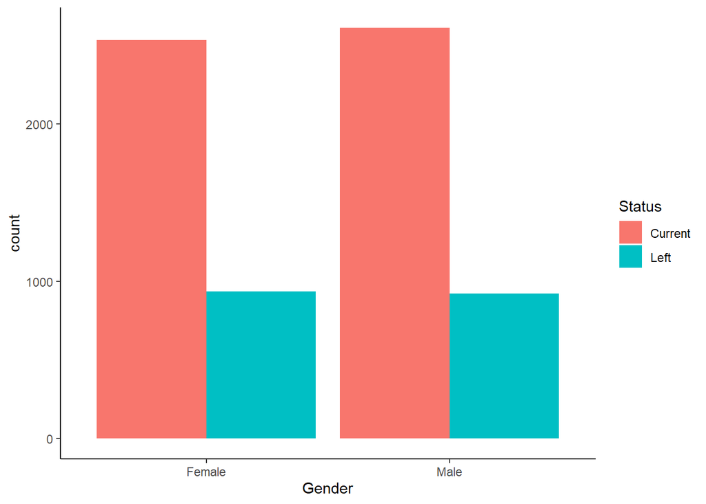

```r
ggplot(CustomerRetention, aes(x = Gender, fill = Status)) +
    geom_bar(position = position_dodge()) +
    theme_classic()
```

The frequency of current was much higher in both genders.

## Partner

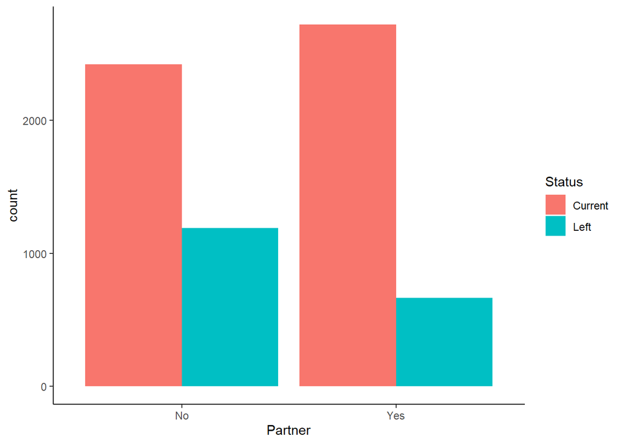

```r
ggplot(CustomerRetention, aes(x = Partner, fill =  Status)) +
    geom_bar(position = position_dodge()) +
    theme_classic()
```

The frequency of current was much higher in No and Yes.

## SeniorCitizen

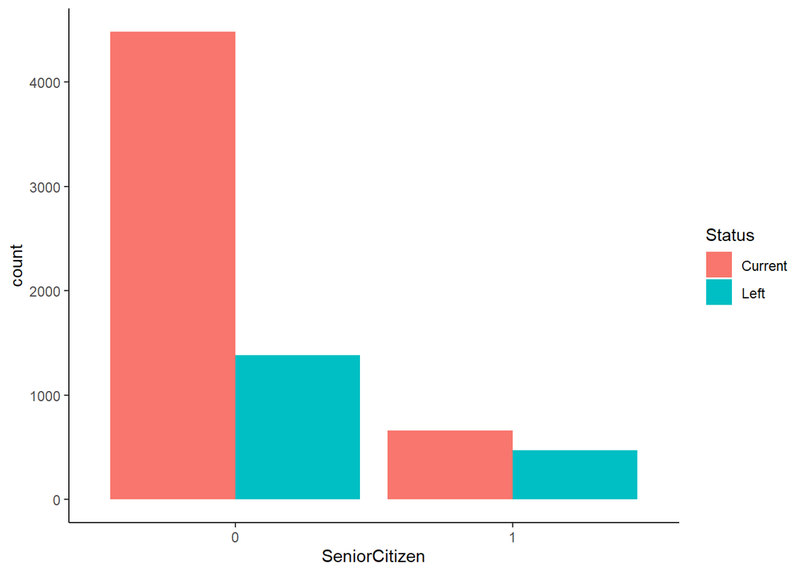

```r
ggplot(CustomerRetention, aes(x = SeniorCitizen, fill = Status)) +
    geom_bar(position = position_dodge()) +
    theme_classic()
```

## Dependents

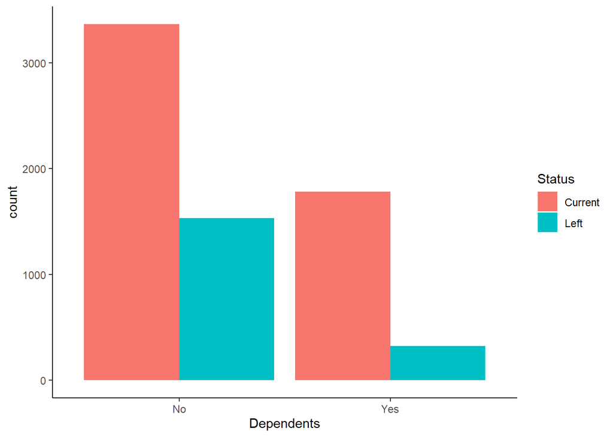

```r
ggplot(CustomerRetention, aes(x = Dependents, fill = Status)) +
    geom_bar(position = position_dodge()) +
    theme_classic()
```

The frequency of current was much higher in No and Yes in Dependents.

## Tenure

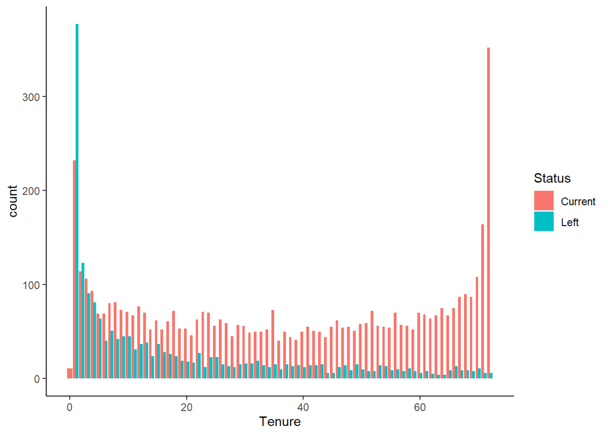

```r
ggplot(CustomerRetention, aes(x = Tenure, fill = Status)) +
    geom_bar(position = position_dodge()) +
    theme_classic()
```

## Scatterplot of Tenure against MonthlyCharge

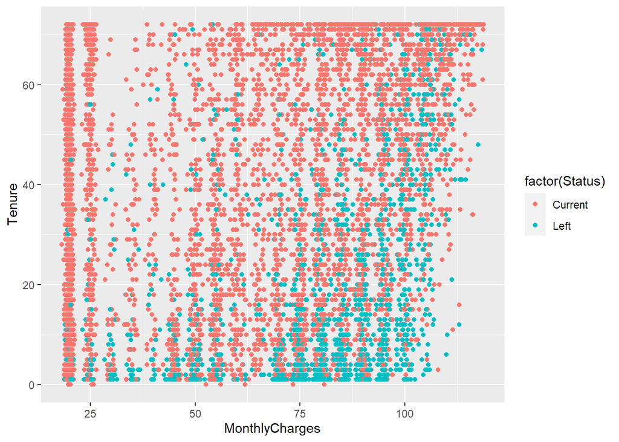

```r
ggplot(CustomerRetention, aes(y = Tenure,x=MonthlyCharges)) +
    geom_point(aes(color = factor(Status)))
```

There is no linear relationship between Tenure and MonthlyCharge nor no trend in the plot.

## PhoneService

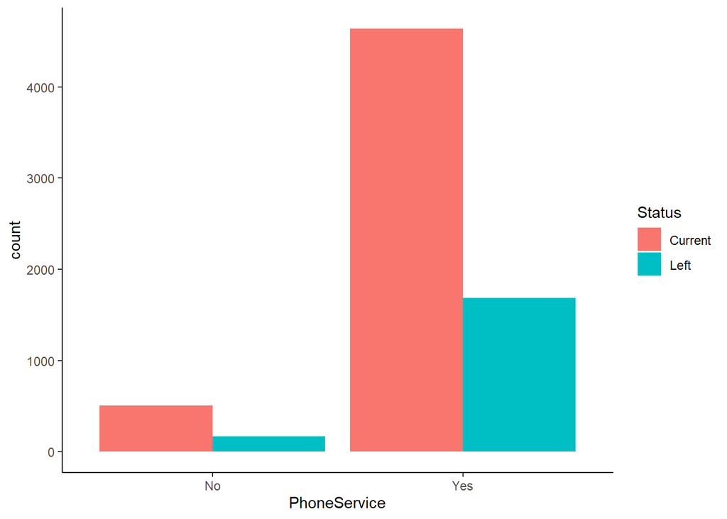

```r
ggplot(CustomerRetention, aes(x = PhoneService, fill = Status)) +
    geom_bar(position = position_dodge()) +
    theme_classic()
```

The frequency of current was much higher in No and Yes in PhoneService. ## MultipleLines

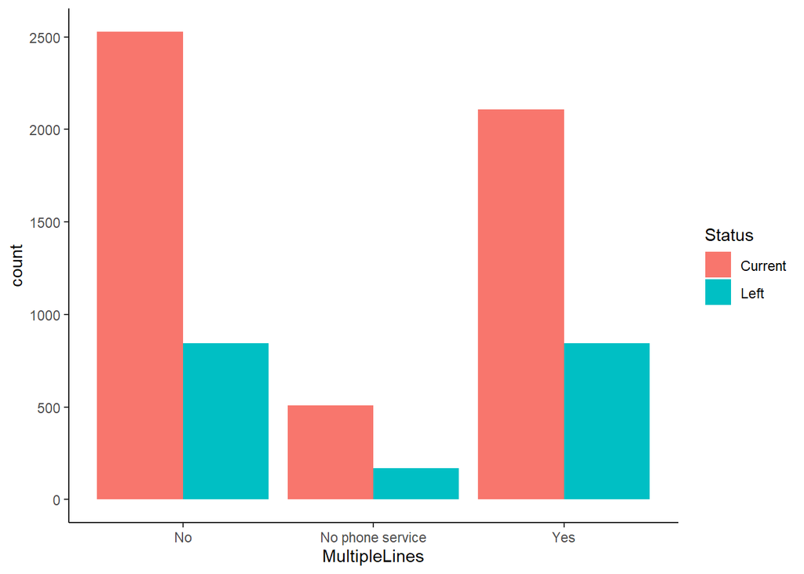

```r
ggplot(CustomerRetention, aes(x = MultipleLines, fill = Status)) +
    geom_bar(position = position_dodge()) +
    theme_classic()
```

The frequency of current was much higher in No,No phone service and Yes in MultipleLines.

## InternetService

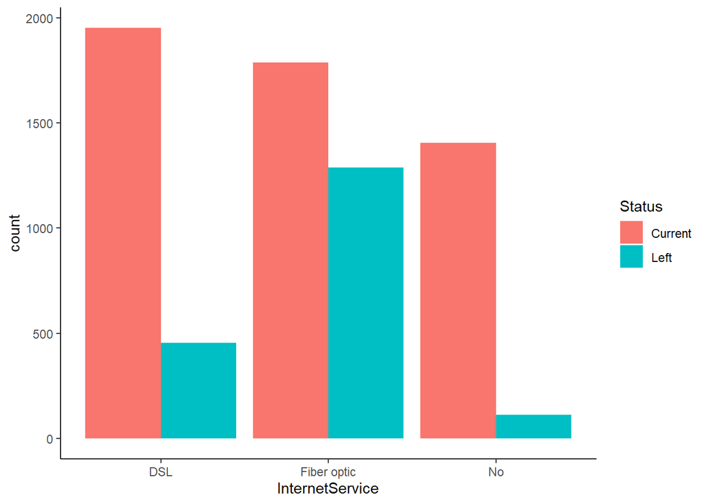

```r
ggplot(CustomerRetention, aes(x = InternetService, fill = Status)) +
    geom_bar(position = position_dodge()) +
    theme_classic()
```

The frequency of current was much higher in DSL,Fiber optic and No in internetService.

## OnlineSecurity

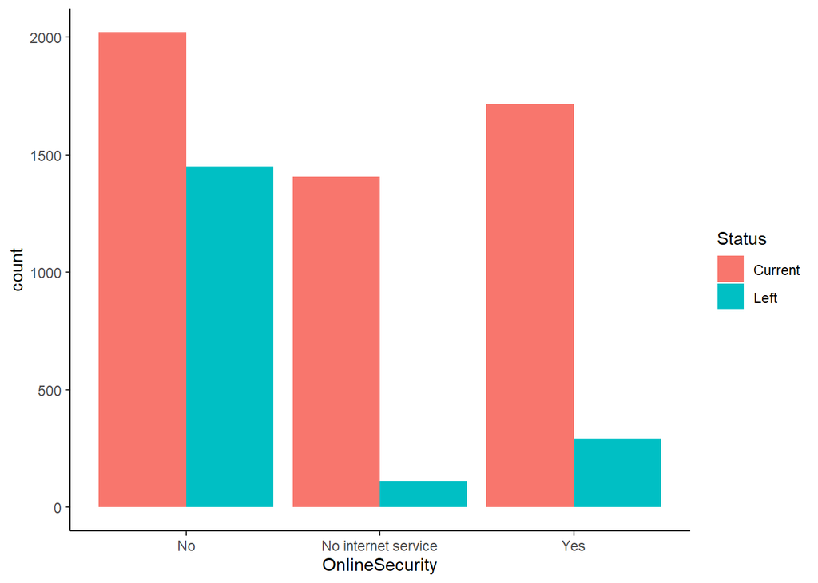

```r
ggplot(CustomerRetention, aes(x = OnlineSecurity , fill = Status)) +
    geom_bar(position = position_dodge()) +
    theme_classic()
```

The frequency of current was much higher in No,No internet service and No in OnlineSecurity .

## OnlineBackup

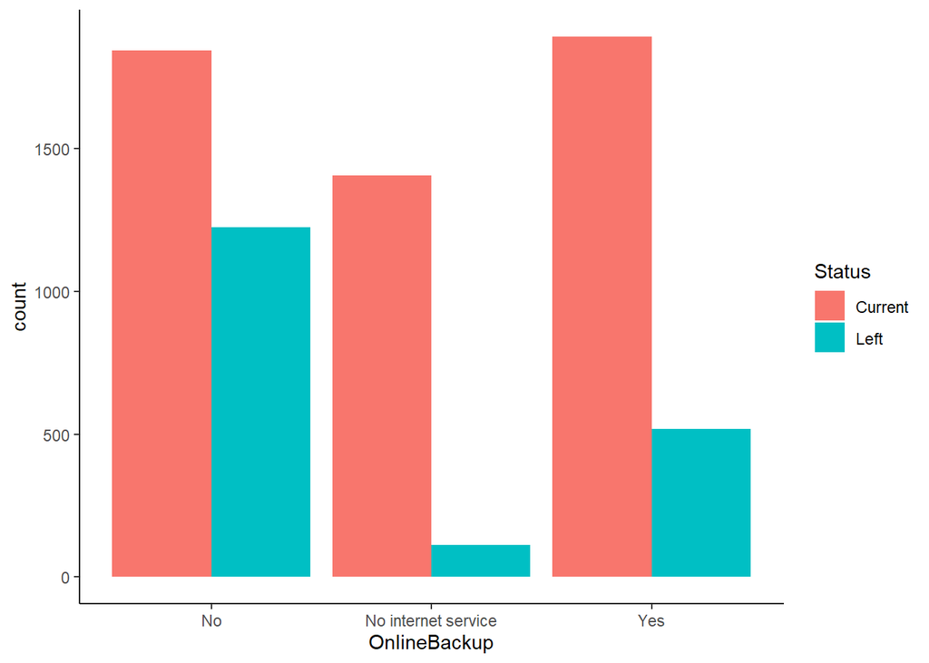

```r
ggplot(CustomerRetention, aes(x = OnlineBackup  , fill = Status)) +
    geom_bar(position = position_dodge()) +
    theme_classic()
```

The frequency of current was much higher in No,No internet service and Yes in OnlineBackup.

## DeviceProtection

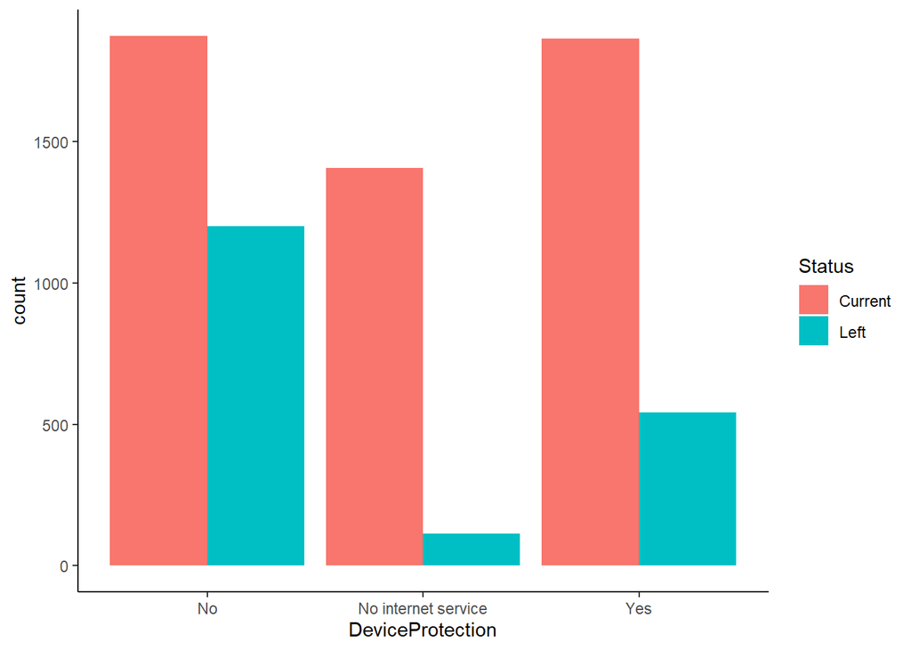

```r
ggplot(CustomerRetention, aes(x = DeviceProtection  , fill = Status)) +
    geom_bar(position = position_dodge()) +
    theme_classic()
```

The frequency of current was much higher in No,No internet service and Yes in DeviceProtection.

## TechSupport

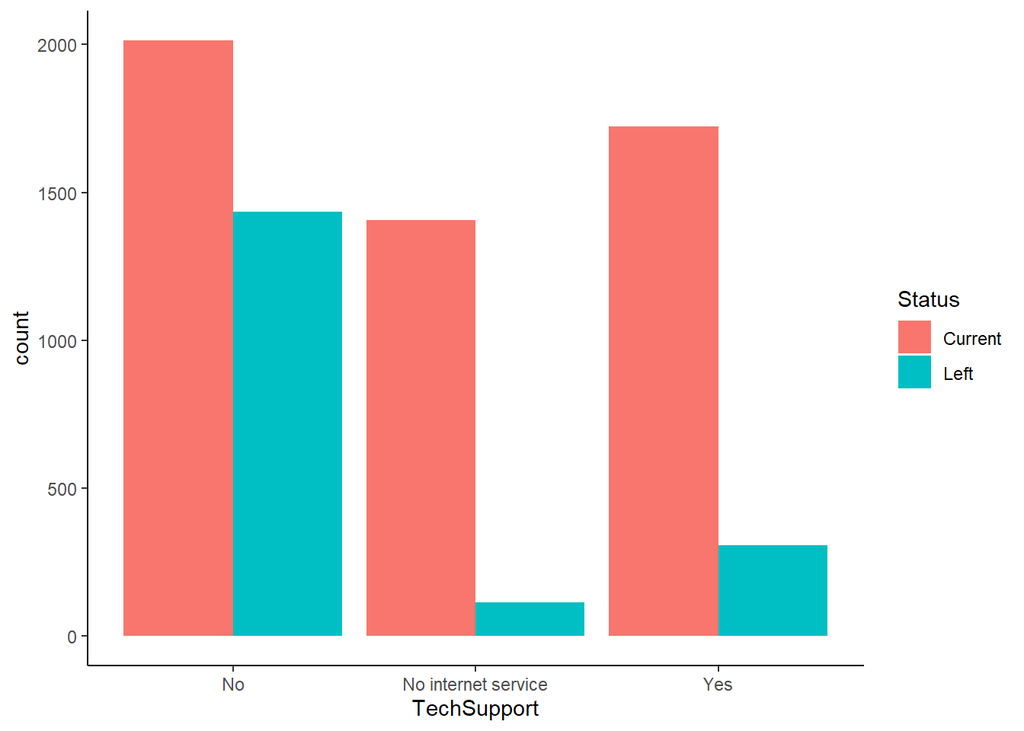

```r
ggplot(CustomerRetention, aes(x = TechSupport , fill = Status)) +
    geom_bar(position = position_dodge()) +
    theme_classic()
```

The frequency of current was much higher in No,No internet service and Yes in TechSupport.

## StreamingTV

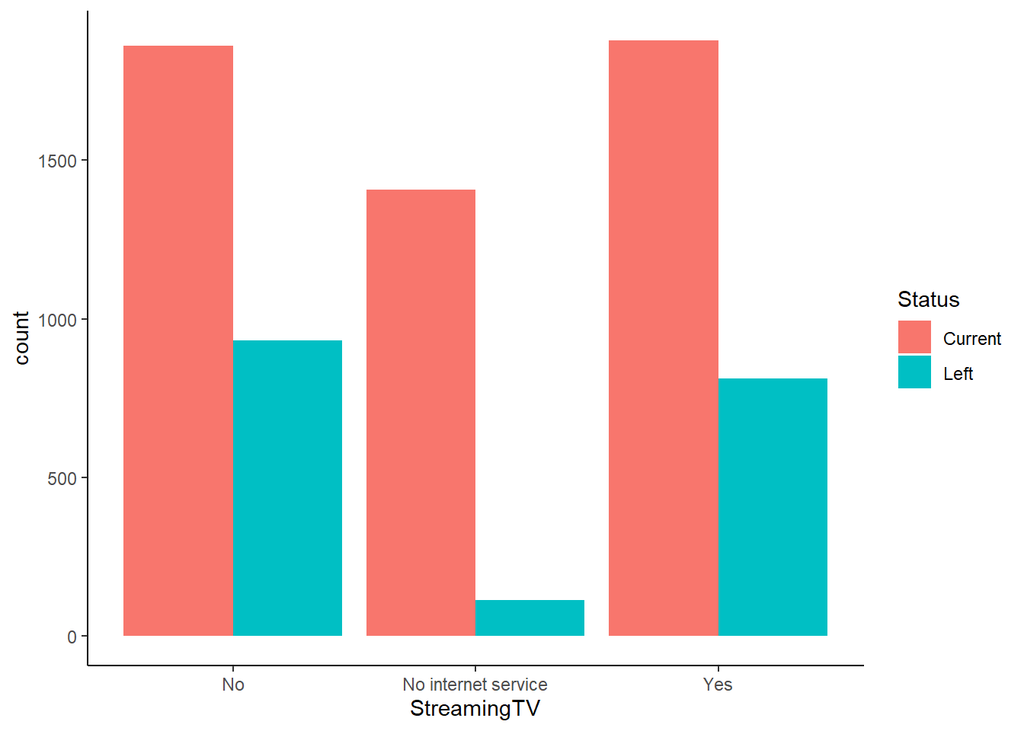

```r
ggplot(CustomerRetention, aes(x = StreamingTV  , fill = Status)) +
    geom_bar(position = position_dodge()) +
    theme_classic()
```

The frequency of current was much higher in No,No internet service and Yes in StreamingTV.

## StreamingMovies

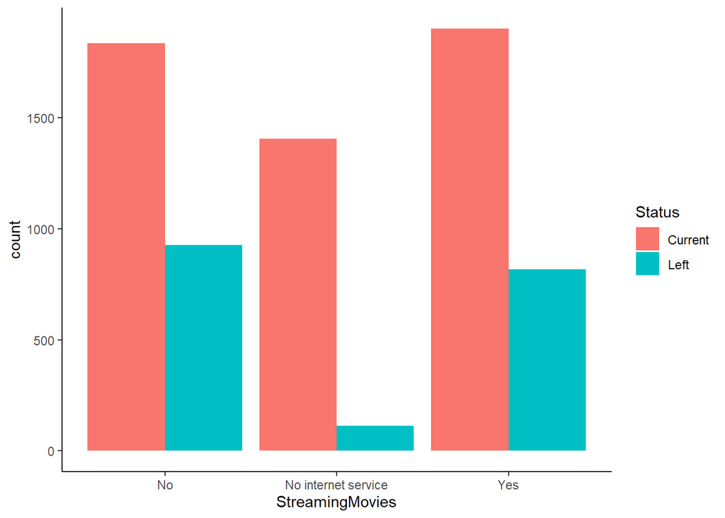

```r
ggplot(CustomerRetention, aes(x = StreamingMovies  , fill = Status)) +
    geom_bar(position = position_dodge()) +
    theme_classic()
```

The frequency of current was much higher in No,No internet service and Yes in StreamingMovies.

## Contract

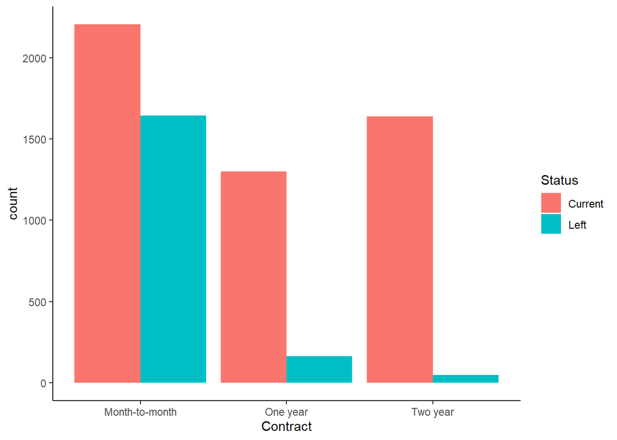

```r
ggplot(CustomerRetention, aes(x = Contract , fill = Status)) +
    geom_bar(position = position_dodge()) +
    theme_classic()
```

## PaperlessBilling

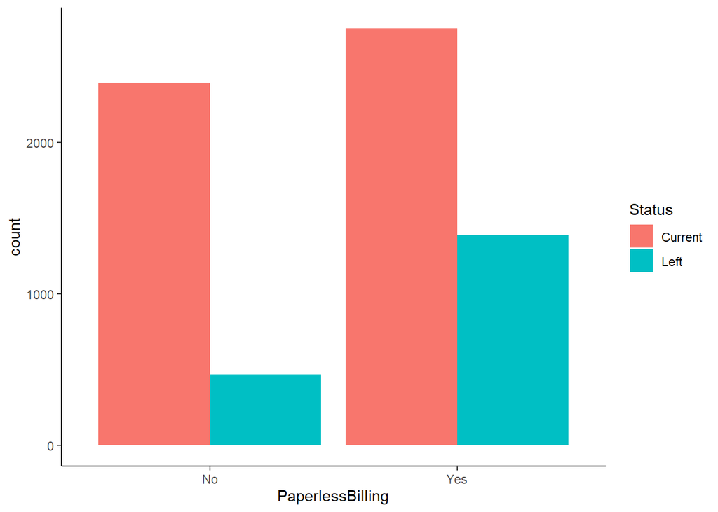

```r
ggplot(CustomerRetention, aes(x = PaperlessBilling , fill = Status)) +
    geom_bar(position = position_dodge()) +
    theme_classic()
```

The frequency of current was much higher in No and Yes in PaperlessBilling.

## PaymentMethod

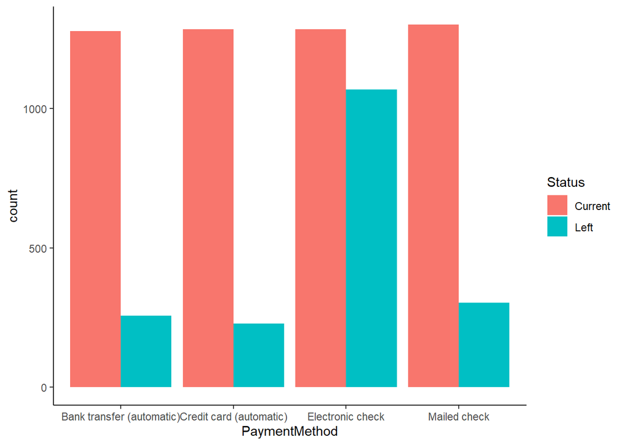

```r
ggplot(CustomerRetention, aes(x =  PaymentMethod , fill = Status)) +
    geom_bar(position = position_dodge()) +
    theme_classic()
```

The frequency of current was much higher in Electronic check,Mailed check,Bank Transer and Credit card in PaymentMethod.

- Create any new columns if you need to at this point.
- Once you are done with the above, split the data set randomly into a training set (80%) and a test set (20%). ## split the data set randomly into a training set (80%) and a test set (20%)

```r
# Set seed for reproducibility of analysis
set.seed(21)

# Create a vector of random numbers to select the row numbers that we will use as training observations
train <- sample(1:6999,  5600)

# Create the test set
df.train <- CustomerRetention[train,]

# Create the test set
df.test <- CustomerRetention[-train,]
```

2. Logistic Regression
- Use the training set to build a Logistic Regression model to predict the probability for losing a customer.

```r
# Store the Logistic Regression model in LogisticModel
LogisticModel.train <- glm(Status ~ ., data = df.train, family = binomial)

# Create the summary of the Logistic Regression Model
summary(LogisticModel.train)
```

```
Call:
glm(formula = Status ~ ., family = binomial, data = df.train)

Deviance Residuals:
    Min       1Q   Median       3Q      Max
-1.9039  -0.6901  -0.2811   0.7485   3.4346

Coefficients: (7 not defined because of singularities)
                                        Estimate  Std. Error z value             Pr(>|z|)
(Intercept)                           1.00335563  0.90802383   1.105               0.2692
GenderMale                           -0.02311803  0.07230618  -0.320               0.7492
SeniorCitizen1                        0.18484835  0.09340678   1.979               0.0478 *
PartnerYes                           -0.04562400  0.08627929  -0.529               0.5969
DependentsYes                        -0.18293351  0.09974554  -1.834               0.0667 .
Tenure                               -0.06291879  0.00696366  -9.035 < 0.0000000000000002 ***
PhoneServiceYes                      -0.11828856  0.72247739  -0.164               0.8699
MultipleLinesNo phone service                 NA          NA      NA                   NA
MultipleLinesYes                      0.38352683  0.19727625   1.944               0.0519 .
InternetServiceFiber optic            1.41440918  0.88740175   1.594               0.1110
InternetServiceNo                    -1.46542424  0.89929328  -1.630               0.1032
OnlineSecurityNo internet service             NA          NA      NA                   NA
OnlineSecurityYes                    -0.32582845  0.19876740  -1.639               0.1012
OnlineBackupNo internet service               NA          NA      NA                   NA
OnlineBackupYes                      -0.04926823  0.19555449  -0.252               0.8011
DeviceProtectionNo internet service           NA          NA      NA                   NA
DeviceProtectionYes                   0.09890139  0.19781275   0.500               0.6171
TechSupportNo internet service                NA          NA      NA                   NA
TechSupportYes                       -0.22605001  0.20083454  -1.126               0.2604
StreamingTVNo internet service                NA          NA      NA                   NA
StreamingTVYes                        0.41111343  0.36278260   1.133               0.2571
StreamingMoviesNo internet service            NA          NA      NA                   NA
StreamingMoviesYes                    0.45653503  0.36385236   1.255               0.2096
ContractOne year                     -0.61020562  0.11995179  -5.087     0.00000036359842 ***
ContractTwo year                     -1.33257698  0.19453255  -6.850     0.00000000000738 ***
PaperlessBillingYes                   0.34891526  0.08303345   4.202     0.00002644444500 ***
PaymentMethodCredit card (automatic) -0.23178617  0.12792622  -1.812               0.0700 .
PaymentMethodElectronic check         0.26695748  0.10468556   2.550               0.0108 *
PaymentMethodMailed check            -0.11362624  0.12854406  -0.884               0.3767
MonthlyCharges                       -0.02770871  0.03535688  -0.784               0.4332
TotalCharges                          0.00036606  0.00007892   4.638     0.00000351571815 ***
---
Signif. codes:  0 '***' 0.001 '**' 0.01 '*' 0.05 '.' 0.1 ' ' 1

(Dispersion parameter for binomial family taken to be 1)

    Null deviance: 6528.5  on 5599  degrees of freedom
Residual deviance: 4670.8  on 5576  degrees of freedom
AIC: 4718.8

Number of Fisher Scoring iterations: 6
```

*OBSERVATION:* The performance of our logistic regression is evaluated with specific key metrics;

## Make predictions

```r
# suppress the warnings by setting warn=-1
options(warn=-1)

Predictions_Probabilities <- predict(LogisticModel.train, type = "response", newdata = df.test)

# Create a vector of prediction classes based on the value of the prediction probability
Prediction_Classes <- ifelse(Predictions_Probabilities > 0.5, "Current", "Left")

# Use the table function and use the prediction classes and the actual classes as the inputs
table(Prediction_Classes, df.test$Status)
```

```
Prediction_Classes Current Left
           Current     104  189
           Left        949  157
```

## Plotting ROC

```r
# suppress the warnings by setting warn=-1
options(warn=-1)

library(pROC)

#define object to plot and calculate AUC
rocobj <- roc(df.test$Status,Predictions_Probabilities)
auc <- round(auc(df.test$Status,Predictions_Probabilities),4)
```

[output not shown]

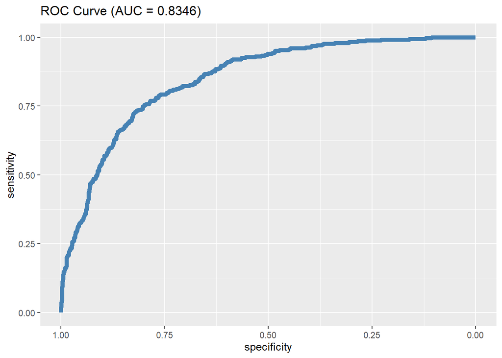

```r
#create ROC plot
ggroc(rocobj, colour = 'steelblue', size = 2) +
  ggtitle(paste0('ROC Curve ', '(AUC = ', auc, ')'))
```

- Try different combinations of variables and arrive at the model that maximizes AUC (Area Under the Curve) for the ROC plots.